# Inflacija i očekivanja potrošača u Hrvatskoj

Ekonomski susreti 2026 · primjer analize

Kako su se kretale godišnja stopa inflacije i očekivanja potrošača o promjenama cijena? Mijenja li se njihova povezanost ako desetljeće podijelimo na dva petogodišnja razdoblja?

## Provjera podataka

Tablica obuhvaća 120 uzastopnih mjeseci, od 2015-01 do 2024-12. Svaki je mjesec zastupljen jednom, a obje su mjere dostupne za svaki mjesec. HICP uspoređuje cijene s istim mjesecom prethodne godine. Saldo iz ankete DG ECFIN sažima očekivanja o kretanju cijena u sljedećih dvanaest mjeseci u usporedbi s proteklih dvanaest. Izražen je u bodovima.

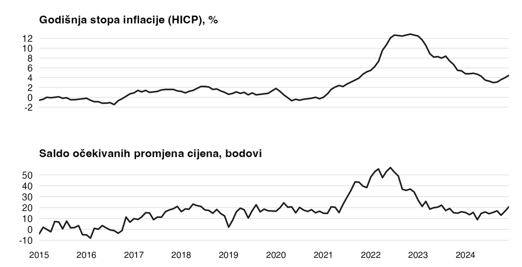

Izvori: Eurostat (HICP) i Europska komisija, DG ECFIN (anketa potrošača, sezonski neprilagođen saldo).

## Godišnji prosjeci

Za svaku godinu računamo aritmetičku sredinu mjesečnih godišnjih stopa i sredinu mjesečnih salda.

| Godina | Inflacija (%) | Saldo (bodovi) | Mjeseci |
| --- | --- | --- | --- |
| 2015 | -0,25 | 1,62 | 12 |
| 2016 | -0,64 | 0,39 | 12 |
| 2017 | 1,31 | 13,88 | 12 |
| 2018 | 1,55 | 17,92 | 12 |
| 2019 | 0,80 | 15,25 | 12 |
| 2020 | 0,04 | 18,47 | 12 |
| 2021 | 2,68 | 28,26 | 12 |
| 2022 | 10,63 | 46,62 | 12 |
| 2023 | 8,47 | 19,80 | 12 |
| 2024 | 4,04 | 15,14 | 12 |

Za provjeru računa, mjesečne stope tijekom 2022. redom iznose 5,5 · 6,3 · 7,3 · 9,6 · 10,7 · 12,1 · 12,7 · 12,6 · 12,5 · 12,7 · 12,9 · 12,7 %. Zbroj od 127,6 dijelimo brojem mjeseci i dobivamo 10,63 %.

## Povezanost unutar istog mjeseca

| Razdoblje | Mjeseci | Pearsonov r |
| --- | --- | --- |
| 2015.–2024. | 120 | 0,6985 |
| 2015.–2019. | 60 | 0,8279 |
| 2020.–2024. | 60 | 0,5342 |

## Zaključak

Od 2021. do 2022. prosjek mjesečnih godišnjih stopa porastao je s 2,68 % na 10,63 %, a prosječni saldo s 28,26 na 46,62 boda. Na mjesečnom grafu vidimo da saldo ranije doseže vrh. Povezanost je jača u prvoj polovini razdoblja (0,8279) nego u drugoj (0,5342). Ta usporedba ostavlja otvorenima pitanja uzroka i prediktivne vrijednosti očekivanja.